# Süper Lig xG Analysis

Author

GADATASARAY Team

```r
# TÜM PROJE İÇİN GEREKLİ ORTAK KÜTÜPHANELER
library(readr)
library(dplyr)
library(ggplot2)
library(tidyr)
library(knitr)

# BÜTÜN CSV DOSYALARININ TEK MERKEZDEN OKUNMASI
s18 <- read_csv("data/raw/turkey-super-lig-teams-2018-to-2019-stats.csv", show_col_types = FALSE)
s19 <- read_csv("data/raw/turkey-super-lig-teams-2019-to-2020-stats.csv", show_col_types = FALSE)
s20 <- read_csv("data/raw/turkey-super-lig-teams-2020-to-2021-stats.csv", show_col_types = FALSE)
s21 <- read_csv("data/raw/turkey-super-lig-teams-2021-to-2022-stats.csv", show_col_types = FALSE)
s22 <- read_csv("data/raw/turkey-super-lig-teams-2022-to-2023-stats.csv", show_col_types = FALSE)
s23 <- read_csv("data/raw/turkey-super-lig-teams-2023-to-2024-stats.csv", show_col_types = FALSE)
s24 <- read_csv("data/raw/turkey-super-lig-teams-2024-to-2025-stats.csv", show_col_types = FALSE)
s25 <- read_csv("data/raw/turkey-super-lig-teams-2025-to-2026-stats.csv", show_col_types = FALSE)

# ORTAK VERİ SETİNİN OLUŞTURULMASI
superlig_data <- bind_rows(s18, s19, s20, s21, s22, s23, s24, s25) %>%
  mutate(
    season_short = paste0(substr(season, 3, 4), "-", substr(season, 8, 9)),

    team_short = case_when(
      common_name == "Galatasaray" ~ "GS",
      common_name == "Fenerbahce" ~ "FB",
      common_name == "Fenerbahçe" ~ "FB",
      common_name == "Besiktas" ~ "BJK",
      common_name == "Beşiktaş" ~ "BJK",
      common_name == "Trabzonspor" ~ "TS",
      common_name == "Istanbul Basaksehir" ~ "IBFK",
      common_name == "İstanbul Başakşehir" ~ "IBFK",
      common_name == "Antalyaspor" ~ "ANT",
      common_name == "Kasimpasa" ~ "KAS",
      common_name == "Kasımpaşa" ~ "KAS",
      common_name == "Kayserispor" ~ "KAY",
      common_name == "Konyaspor" ~ "KON",
      common_name == "Sivasspor" ~ "SVS",
      TRUE ~ common_name
    ),

    finishing_diff = goals_scored_per_match - xg_for_avg_overall,
    total_xg = xg_for_avg_overall * matches_played,
    total_goals = goals_scored_per_match * matches_played,
    total_finishing_diff = total_goals - total_xg,

    shots_per_match = shots / matches_played,
    xg_per_shot = total_xg / shots,
    shot_quality = xg_per_shot
  )

# KODLAR İÇİN KÖPRÜ (Eksik .RData dosyası yerine CSV'leri kullanıyoruz)
core_data_cleaned <- superlig_data %>%
  mutate(goals_minus_xg = goals_scored_per_match - xg_for_avg_overall)
```

## Section 1 – Understanding Expected Goals and Match Performance

Expected Goals, commonly known as xG, is a football analytics metric that estimates the quality of chances created by a team. It does not directly measure the final score. Instead, it shows how many goals a team would be expected to score based on the quality of its chances.

In this section, we analyze how xG is related to different performance indicators in the Turkish Süper Lig.

### 1.1 Correlation Between xG and Performance Indicators

Before focusing only on goals, we first compare the relationship between xG and different performance indicators. This helps us understand whether xG is more closely related to actual goals, shooting performance, or overall league performance.

```r
xg_correlations <- tibble::tibble(
  relationship = c(
    "xG vs Goals Scored",
    "xG vs Shots on Target",
    "xG vs Shots",
    "xG vs Points per Game"
  ),
  correlation = c(
    cor(core_data_cleaned$xg_for_avg_overall,
        core_data_cleaned$goals_scored_per_match,
        use = "complete.obs"),

    cor(core_data_cleaned$xg_for_avg_overall,
        core_data_cleaned$shots_on_target,
        use = "complete.obs"),

    cor(core_data_cleaned$xg_for_avg_overall,
        core_data_cleaned$shots,
        use = "complete.obs"),

    cor(core_data_cleaned$xg_for_avg_overall,
        core_data_cleaned$points_per_game,
        use = "complete.obs")
  )
)

xg_correlations
```

```
# A tibble: 4 × 2
  relationship          correlation
  <chr>                       <dbl>
1 xG vs Goals Scored          0.702
2 xG vs Shots on Target       0.740
3 xG vs Shots                 0.829
4 xG vs Points per Game       0.714
```

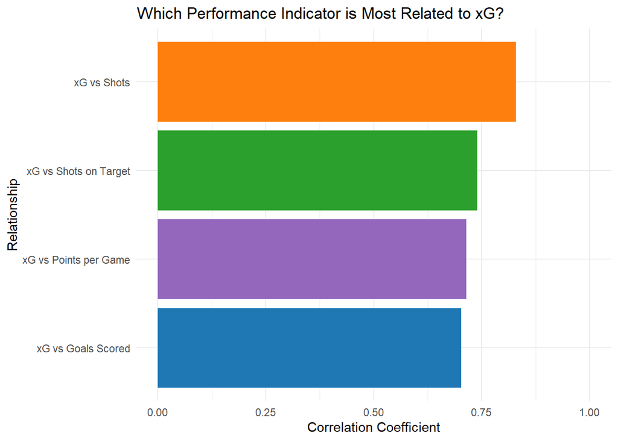

Correlation between xG and selected performance indicators

```r
ggplot(xg_correlations, aes(x = reorder(relationship, correlation), y = correlation, fill = relationship)) +
  geom_col(show.legend = FALSE) +
  coord_flip() +
  labs(
    title = "Which Performance Indicator is Most Related to xG?",
    x = "Relationship",
    y = "Correlation Coefficient"
  ) +
  ylim(0, 1) +
  scale_fill_manual(values = c(
    "xG vs Goals Scored" = "#1f77b4",
    "xG vs Shots on Target" = "#2ca02c",
    "xG vs Shots" = "#ff7f0e",
    "xG vs Points per Game" = "#9467bd"
  )) +
  theme_minimal()
```

The bar chart compares the strength of the relationship between xG and selected performance indicators. A higher correlation means that the variable has a stronger positive relationship with xG.

Since xG is designed to measure expected scoring performance, we expect the relationship between xG and goals scored to be one of the most meaningful comparisons. However, shots on target and points per game can also provide useful context about attacking and overall team performance.

### 1.2 xG vs Goals Scored

The first direct relationship we analyze is xG and actual goals scored. This is the most natural comparison because xG is designed to estimate expected scoring performance.

```r
cor_xg_goals <- cor(
  core_data_cleaned$xg_for_avg_overall,
  core_data_cleaned$goals_scored_per_match,
  use = "complete.obs"
)

cor_xg_goals
```

```
[1] 0.702281
```

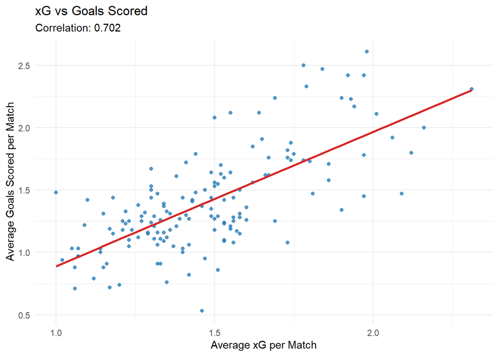

Relationship between xG and goals scored per match

```r
ggplot(
  core_data_cleaned,
  aes(x = xg_for_avg_overall, y = goals_scored_per_match)
) +
  geom_point(alpha = 0.75, color = "#1f77b4") +
geom_smooth(method = "lm", se = FALSE, color = "#d62728", linewidth = 1) +
  labs(
    title = "xG vs Goals Scored",
    subtitle = paste("Correlation:", round(cor_xg_goals, 3)),
    x = "Average xG per Match",
    y = "Average Goals Scored per Match"
  ) +
  theme_minimal()
```

The scatter plot shows a positive relationship between xG and goals scored. This means that teams creating higher-quality chances generally score more goals.

However, the relationship is not perfect. The points are not located exactly on a single straight line. This is expected because actual goals are affected by finishing quality, goalkeeper performance, defensive pressure, and randomness.

Therefore, xG is useful for explaining scoring performance, but it should not be interpreted as a perfect predictor of goals.

### 1.3 xG vs Shots on Target

Next, we compare xG with shots on target. This relationship is useful because shots on target show how often a team produces direct scoring threats.

```r
cor_xg_sot <- cor(
  core_data_cleaned$xg_for_avg_overall,
  core_data_cleaned$shots_on_target,
  use = "complete.obs"
)

cor_xg_sot
```

```
[1] 0.739523
```

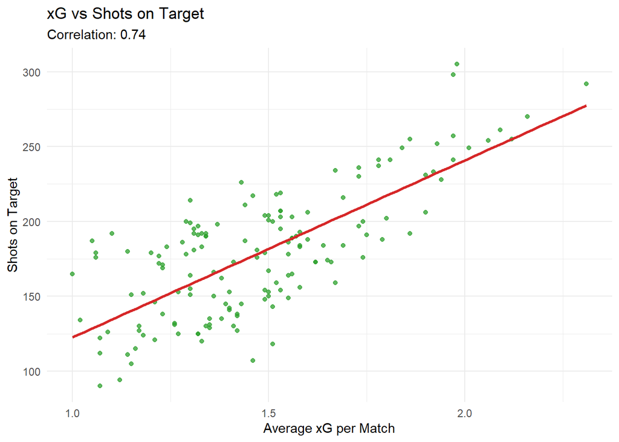

Relationship between xG and shots on target

```r
ggplot(
  core_data_cleaned,
  aes(x = xg_for_avg_overall, y = shots_on_target)
) +
  geom_point(alpha = 0.75, color = "#2ca02c") +
geom_smooth(method = "lm", se = FALSE, color = "#d62728", linewidth = 1) +
  labs(
    title = "xG vs Shots on Target",
    subtitle = paste("Correlation:", round(cor_xg_sot, 3)),
    x = "Average xG per Match",
    y = "Shots on Target"
  ) +
  theme_minimal()
```

The relationship between xG and shots on target helps us understand whether teams with higher expected goals also produce more accurate attacking attempts.

### 1.4 xG vs Points per Game

We also analyze the relationship between xG and points per game. This comparison is more indirect than the relationship between xG and goals because points are affected by both attacking and defensive performance.

```r
cor_xg_points <- cor(
  core_data_cleaned$xg_for_avg_overall,
  core_data_cleaned$points_per_game,
  use = "complete.obs"
)

cor_xg_points
```

```
[1] 0.7140412
```

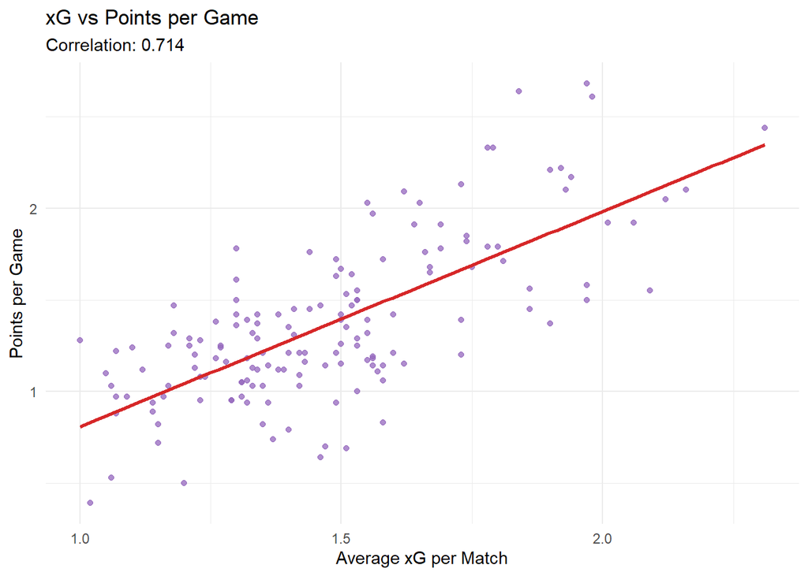

Relationship between xG and points per game

```r
ggplot(
  core_data_cleaned,
  aes(x = xg_for_avg_overall, y = points_per_game)
) +
  geom_point(alpha = 0.75, color = "#9467bd") +
geom_smooth(method = "lm", se = FALSE, color = "#d62728", linewidth = 1) +
  labs(
    title = "xG vs Points per Game",
    subtitle = paste("Correlation:", round(cor_xg_points, 3)),
    x = "Average xG per Match",
    y = "Points per Game"
  ) +
  theme_minimal()
```

### 1.5 xGA vs Goals Conceded

Finally, we analyze the defensive side by comparing xGA and goals conceded. xGA represents the quality of chances that a team allows its opponents to create.

```r
cor_xga_conceded <- cor(
  core_data_cleaned$xg_against_avg_overall,
  core_data_cleaned$goals_conceded_per_match,
  use = "complete.obs"
)

cor_xga_conceded
```

```
[1] 0.652705
```

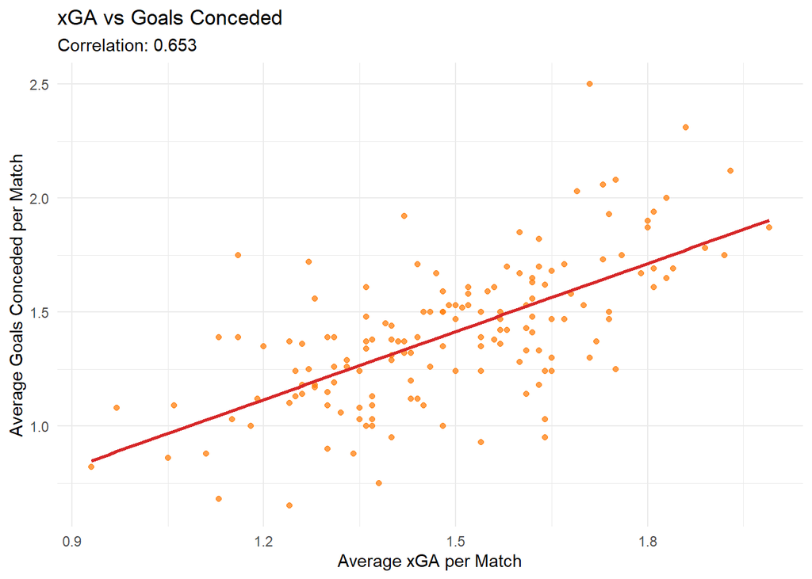

Relationship between xGA and goals conceded per match

```r
ggplot(
  core_data_cleaned,
  aes(x = xg_against_avg_overall, y = goals_conceded_per_match)
) +
  geom_point(alpha = 0.75, color = "#ff7f0e") +
geom_smooth(method = "lm", se = FALSE, color = "#d62728", linewidth = 1) +
  labs(
    title = "xGA vs Goals Conceded",
    subtitle = paste("Correlation:", round(cor_xga_conceded, 3)),
    x = "Average xGA per Match",
    y = "Average Goals Conceded per Match"
  ) +
  theme_minimal()
```

### 1.6 Why is the Correlation Not Equal to 1?

Although xG is related to goals and other performance indicators, the correlation is not expected to be exactly 1. This is because xG measures probability, not certainty.

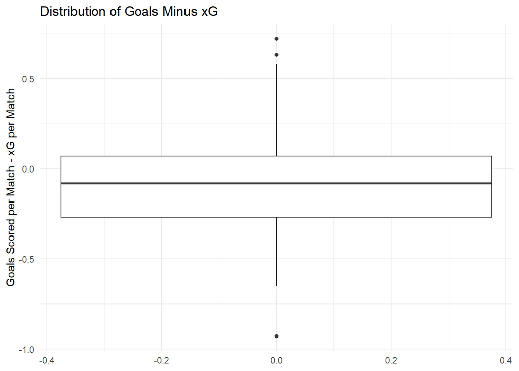

Distribution of goals minus xG

```r
ggplot(core_data_cleaned, aes(y = goals_minus_xg)) +
  geom_boxplot() +
  labs(
    title = "Distribution of Goals Minus xG",
    y = "Goals Scored per Match - xG per Match"
  ) +
  theme_minimal()
```

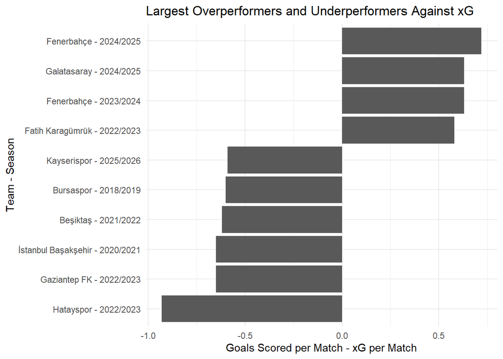

Largest differences between goals and xG

```r
core_data_cleaned %>%
  arrange(desc(abs(goals_minus_xg))) %>%
  slice_head(n = 10) %>%
  mutate(team_season = paste(common_name, season, sep = " - ")) %>%
  ggplot(aes(x = reorder(team_season, goals_minus_xg), y = goals_minus_xg)) +
  geom_col() +
  coord_flip() +
  labs(
    title = "Largest Overperformers and Underperformers Against xG",
    x = "Team - Season",
    y = "Goals Scored per Match - xG per Match"
  ) +
  theme_minimal()
```

> *Section 1 Summary:* This section shows that xG is positively related to actual goals scored, shots on target, and points per game. The relationship between xG and actual performance is not perfect. xG measures chance quality, not guaranteed goals.

## Section 2 - xG Evolution and Finishing Performance in the Süper Lig

This section analyzes how expected goals (xG) evolved across recent Süper Lig seasons and examines the relationship between xG and actual goal-scoring performance. The analysis focuses on xG accuracy, finishing differences, shot quality, and home advantage in order to better understand both the strengths and limitations of xG as a predictive metric in football analytics.

### 2.1 Evolution of xG Accuracy

To understand whether expected goals consistently explains attacking performance in the Süper Lig, we examine the correlation between xG per match and goals scored per match across different seasons.

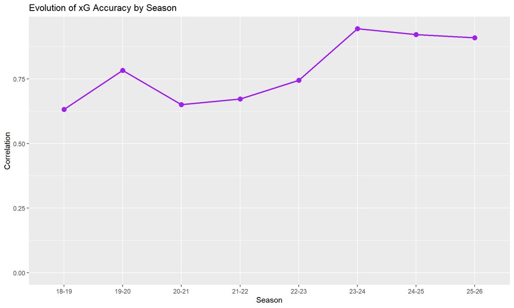

```r
seasonal_xg_accuracy <- superlig_data %>%
  group_by(season_short) %>%
  summarize(
    correlation = cor(xg_for_avg_overall, goals_scored_per_match),
    .groups = "drop"
  )

seasonal_xg_accuracy %>%
  ggplot(aes(x = season_short, y = correlation, group = 1)) +
  geom_line(color = "purple", linewidth = 1) +
  geom_point(size = 3, color = "purple") +
  expand_limits(y = 0) +
  xlab("Season") +
  ylab("Correlation") +
  ggtitle("Evolution of xG Accuracy by Season")
```

*Analytical Insight:*  
The relationship between xG and actual goals becomes noticeably stronger in recent seasons, with correlation values rising above 0.9 after the 2022–23 season. One important reason behind this improvement is the evolution of xG models themselves. Early xG models mainly relied on basic variables such as shot distance and shooting angle, while modern models incorporate much more detailed contextual information including body part used, defensive pressure, goalkeeper positioning, pass type, and shot location dynamics. As football data collection and machine learning methods improved over time, xG models became more capable of capturing the true quality of scoring opportunities. However, since the correlation never reaches 1, actual goal scoring is still influenced by finishing ability, tactical context, and natural randomness in football.

### 2.2 Why xG is not Perfect

Although expected goals strongly correlates with actual goal scoring, xG represents probability rather than certainty. It estimates how likely similar shots are to become goals over the long run rather than predicting the exact outcome of every individual attempt.

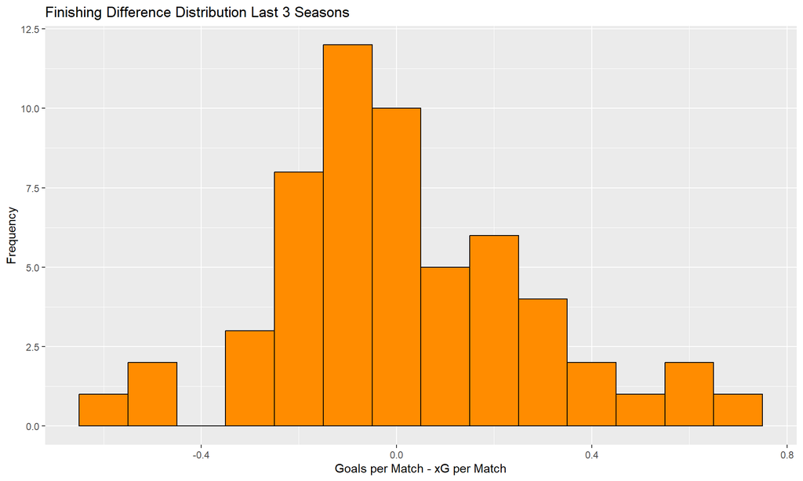

```r
last3seasons_data <- superlig_data %>%
  filter(season_short %in% c("23-24", "24-25", "25-26"))

last3seasons_data %>%
  ggplot(aes(x = finishing_diff)) +
  geom_histogram(
    binwidth = 0.10,
    fill = "darkorange",
    color = "black"
  ) +
  xlab("Goals per Match - xG per Match") +
  ylab("Frequency") +
  ggtitle("Finishing Difference Distribution Last 3 Seasons")
```

*Analytical Insight:*  
The distribution demonstrates that some teams score more goals than their xG suggests, while others underperform relative to their expected output. This difference exists because xG measures the probability of scoring based on historical shot data rather than guaranteeing outcomes. However, the average finishing difference across all teams is only around 0.0275 goals per match, meaning that over a 36-match season, teams score only about one goal more than expected on average. This suggests that while short-term deviations exist, xG remains highly reliable in the long run.

### 2.3 Total Finishing Sustainability

Do teams consistently score above their expected goals, or is finishing performance mostly random? To explore this, we compared the difference between total goals scored and expected goals (Goals − xG) for big teams and average Süper Lig teams across multiple seasons.

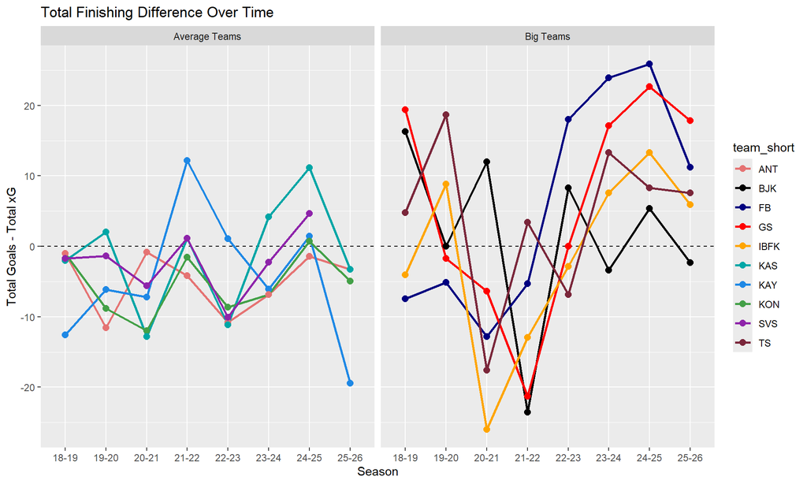

```r
big_teams <- c("GS", "FB", "BJK", "TS", "IBFK")
average_teams <- c("ANT", "KAS", "KAY", "KON", "SVS")

total_finishing_data <- superlig_data %>%
  filter(team_short %in% c(big_teams, average_teams)) %>%
  mutate(
    group = case_when(
      team_short %in% big_teams ~ "Big Teams",
      TRUE ~ "Average Teams"
    )
  )

total_finishing_data %>%
  ggplot(
    aes(
      x = season_short,
      y = total_finishing_diff,
      color = team_short,
      group = team_short
    )
  ) +
  geom_hline(yintercept = 0, linetype = "dashed", color = "black") +
  geom_line(linewidth = 1) +
  geom_point(size = 2.5) +
  facet_wrap(~ group) +
  scale_color_manual(
    values = c(
      "GS" = "red",
      "FB" = "navy",
      "BJK" = "black",
      "TS" = "#7A263A",
      "IBFK" = "orange",
      "ANT" = "#E57373",
      "KAS" = "#00A6A6",
      "KAY" = "#1E88E5",
      "KON" = "#43A047",
      "SVS" = "#8E24AA"
    )
  ) +
  xlab("Season") +
  ylab("Total Goals - Total xG") +
  ggtitle("Total Finishing Difference Over Time")
```

The chart shows that average teams generally stay close to the xG baseline, suggesting that their finishing performance mostly reflects the quality of chances they create. In contrast, big teams display more fluctuating patterns but increasingly outperform their expected goals in recent seasons.

One possible explanation is the arrival of elite strikers such as Osimhen, Icardi, Džeko, and Onuachu, who may convert chances more efficiently than average players.

*Analytical Insight:*  
Elite clubs appear more capable of sustaining positive finishing performance over time, suggesting that high-quality attackers can consistently outperform expected goal models.

### 2.4 Shot Quality Evolution

Has the average quality of shots changed over time in the Süper Lig? To investigate this, we analyzed the average expected goals per shot (xG per shot) across multiple seasons in order to evaluate whether teams are creating more efficient scoring opportunities over time.

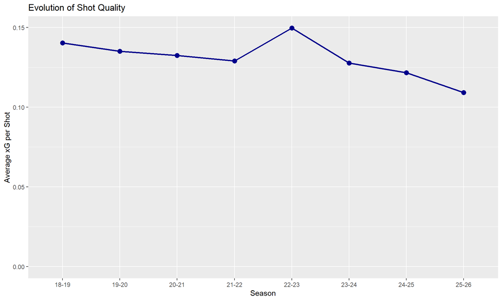

```r
seasonal_shot_quality <- superlig_data %>%
  group_by(season_short) %>%
  summarize(
    average_shot_quality = mean(shot_quality, na.rm = TRUE),
    .groups = "drop"
  )

seasonal_shot_quality %>%
  ggplot(aes(x = season_short, y = average_shot_quality, group = 1)) +
  geom_line(color = "darkblue", linewidth = 1) +
  geom_point(color = "darkblue", size = 3) +
  expand_limits(y = 0) +
  xlab("Season") +
  ylab("Average xG per Shot") +
  ggtitle("Evolution of Shot Quality")
```

The chart shows a gradual decline in shot quality over recent seasons, with average xG per shot decreasing over time. Although the league experienced a temporary peak during the 2022–23 season, the overall trend suggests that teams are increasingly taking lower-quality shots.

One possible explanation is the decreasing dominance of slow possession-based football. Rather than waiting for the “perfect chance,” teams may now prefer quicker and more aggressive attacking sequences. In addition, as discussed in the previous section, the presence of elite finishers may encourage teams to attempt more difficult shots, trusting high-quality strikers to convert opportunities above expectation.

*Analytical Insight:*  
Despite the increasing attacking efficiency of elite clubs, the average quality of individual shots appears to decline over time, suggesting a tactical shift toward faster and more direct attacking football in the modern Süper Lig.

### 2.5 Shot Volume vs Shot Quality

Do teams prioritize creating more shots or creating better shots? To explore this question, we compared average shots per match with average xG per shot over the last three seasons. The dashed lines represent league averages and divide teams into four different attacking profiles.

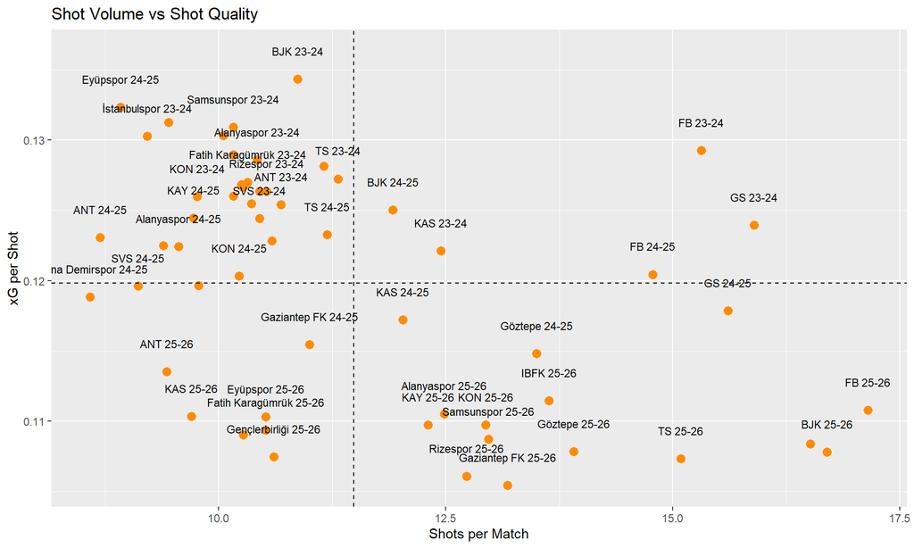

```r
quadrant_data <- superlig_data %>%
  filter(season_short %in% c("23-24", "24-25", "25-26")) %>%
  mutate(label = paste(team_short, season_short))

avg_shots <- mean(quadrant_data$shots_per_match, na.rm = TRUE)
avg_quality <- mean(quadrant_data$xg_per_shot, na.rm = TRUE)

quadrant_data %>%
  ggplot(aes(x = shots_per_match, y = xg_per_shot)) +
  geom_point(size = 3, color = "darkorange") +
  geom_text(
    aes(label = label),
    size = 3,
    nudge_y = 0.002,
    check_overlap = TRUE
  ) +
  geom_vline(xintercept = avg_shots, linetype = "dashed") +
  geom_hline(yintercept = avg_quality, linetype = "dashed") +
  xlab("Shots per Match") +
  ylab("xG per Shot") +
  ggtitle("Shot Volume vs Shot Quality")
```

The quadrant structure reveals distinct attacking identities across the league.

Teams located in the top-right quadrant combine high shot volume with high shot quality, representing the league’s most complete and dominant attacking profiles. Clubs such as Galatasaray and Fenerbahçe frequently appear in this area.

The top-left quadrant contains teams that produce fewer shots but maintain high shot quality. This may reflect a more patient and possession-oriented attacking approach focused on waiting for optimal scoring opportunities. Eyüpspor’s recent positioning in this quadrant is particularly notable and may be associated with Arda Turan’s positional and possession-based tactical influences.

In contrast, teams in the bottom-right quadrant generate high shooting volume despite below-average shot quality. This suggests a more direct and aggressive attacking style that prioritizes frequent attempts over efficiency.

Finally, the bottom-left quadrant represents teams with both low shot volume and low shot quality, indicating limited attacking production overall.

Another notable pattern is that many Anadolu clubs cluster around the efficient but lower-volume top-left area, suggesting that these teams often rely on structured chance creation rather than sustained attacking pressure.

*Analytical Insight:*  
The results suggest that elite teams separate themselves not only through attacking volume but also through maintaining above-average shot quality. At the same time, league-wide patterns indicate a growing tactical divide between possession-oriented efficiency and direct high-volume attacking football.

### 2.6 Home Advantage and xG

Does home advantage still play an important role in attacking production? To examine this, we compared average expected goals (xG) generated by home and away teams across multiple seasons.

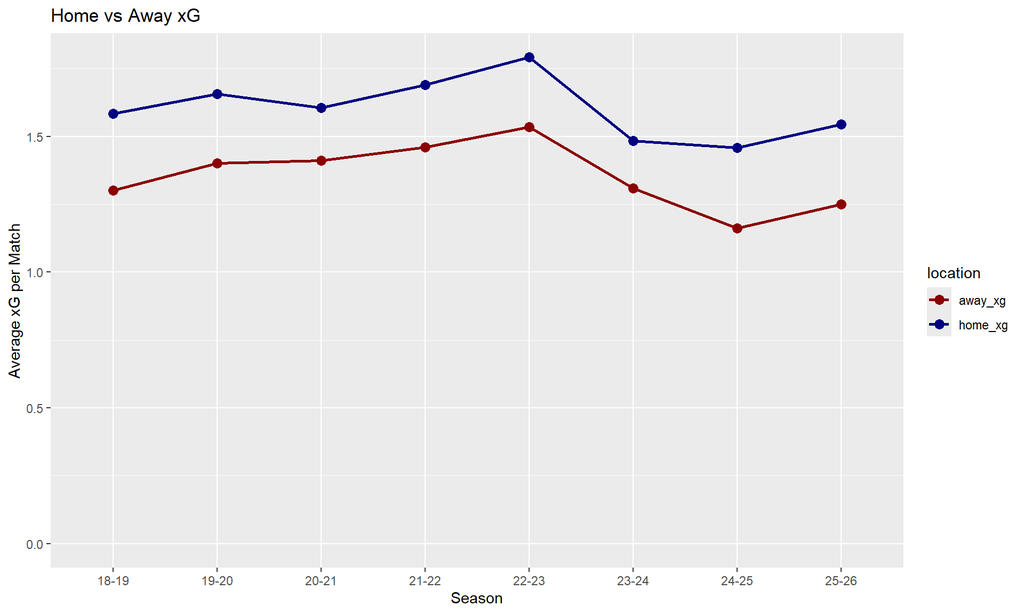

```r
home_away_xg <- superlig_data %>%
  group_by(season_short) %>%
  summarize(
    home_xg = mean(xg_for_avg_home, na.rm = TRUE),
    away_xg = mean(xg_for_avg_away, na.rm = TRUE),
    .groups = "drop"
  )

home_away_long <- home_away_xg %>%
  pivot_longer(
    cols = c(home_xg, away_xg),
    names_to = "location",
    values_to = "xg"
  )

home_away_long %>%
  ggplot(aes(x = season_short, y = xg, color = location, group = location)) +
  geom_line(linewidth = 1) +
  geom_point(size = 3) +
  expand_limits(y = 0) +
  scale_color_manual(
    values = c(
      "home_xg" = "navy",
      "away_xg" = "darkred"
    )
  ) +
  xlab("Season") +
  ylab("Average xG per Match") +
  ggtitle("Home vs Away xG")
```

The chart clearly shows that home teams consistently generate higher xG values than away teams in every season, confirming that home advantage remains an important factor in Süper Lig attacking performance.

Another notable pattern is that the gap between home and away xG remains relatively stable over time. Although both lines fluctuate across seasons, they move in a largely parallel manner, suggesting that league-wide tactical or offensive trends affect both home and away teams similarly without significantly changing the overall home advantage structure.

*Analytical Insight:*  
The findings suggest that home advantage continues to provide a consistent offensive benefit in the Süper Lig, while the stable gap between home and away xG indicates that this advantage has neither significantly increased nor disappeared over time.

## Section 2 Key Takeaways

- Expected goals (xG) has become an increasingly reliable indicator of attacking performance in the Süper Lig, especially in recent seasons where correlations with actual goals exceed 0.9.
- Despite its predictive strength, xG remains a probability-based metric rather than an exact prediction model. Finishing quality, goalkeeper performance, tactical context, and randomness continue to create deviations between xG and actual goals.
- Elite clubs appear more capable of sustaining positive finishing performance over multiple seasons, potentially due to the presence of high-quality attackers who consistently outperform expected goal models.
- Recent seasons show a gradual decline in average shot quality, suggesting a tactical shift toward faster and more direct attacking football rather than slower possession-based chance creation.
- Teams differ significantly in their attacking profiles. While some prioritize shot quantity, others focus on creating fewer but higher-quality opportunities.
- Home advantage continues to play a consistent role in attacking production, with home teams generating higher xG values than away teams across all examined seasons. ## Section 3: xG and Success in the Süper Lig

By analyzing 8 seasons of data, we examine how often tactical systems (metrics) and individual brilliance (skill) intersect to crown a champion.

```r
# Creating xGD and Championship Status for Section 3
analysis_data <- superlig_data %>%
  mutate(
    Season = season_short,
    xGD = xg_for_avg_overall - xg_against_avg_overall,
    is_champion = ifelse(league_position == 1, "Champion", "Other Teams")
  )
```

### 3.1 What Drives Success? (Offense vs. Defense)

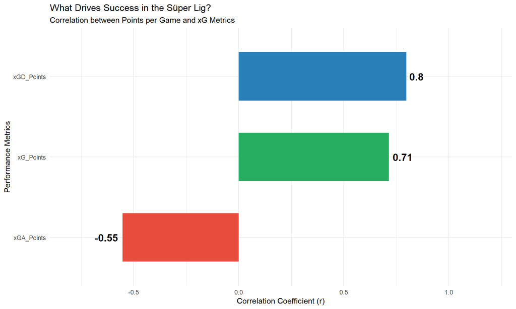

```r
# Correlation Analysis Plot
correlation_df <- analysis_data %>%
  summarise(
    xG_Points = cor(xg_for_avg_overall, points_per_game, use = "complete.obs"),
    xGA_Points = cor(xg_against_avg_overall, points_per_game, use = "complete.obs"),
    xGD_Points = cor(xGD, points_per_game, use = "complete.obs")
  ) %>%
  pivot_longer(cols = everything(), names_to = "Metric", values_to = "Correlation") %>%
  mutate(Strength = abs(Correlation))

ggplot(correlation_df, aes(x = reorder(Metric, Strength), y = Correlation, fill = Metric)) +
  geom_bar(stat = "identity", width = 0.6) +
  geom_text(
    aes(label = round(Correlation, 2)),
    hjust = ifelse(correlation_df$Correlation > 0, -0.2, 1.2),
    size = 5,
    fontface = "bold"
  ) +
  scale_fill_manual(
    values = c(
      "xG_Points" = "#27ae60",
      "xGA_Points" = "#e74c3c",
      "xGD_Points" = "#2980b9"
    )
  ) +
  scale_y_continuous(limits = c(-0.8, 1.2)) +
  coord_flip() +
  labs(
    title = "What Drives Success in the Süper Lig?",
    subtitle = "Correlation between Points per Game and xG Metrics",
    x = "Performance Metrics",
    y = "Correlation Coefficient (r)"
  ) +
  theme_minimal() +
  theme(legend.position = "none")
```

*Analytical Insight:* The data confirms that while attacking and defending are both vital, the most decisive factor for league success is Expected Goal Difference (xGD).

### 3.2 Champion Profiles (The Structural DNA)

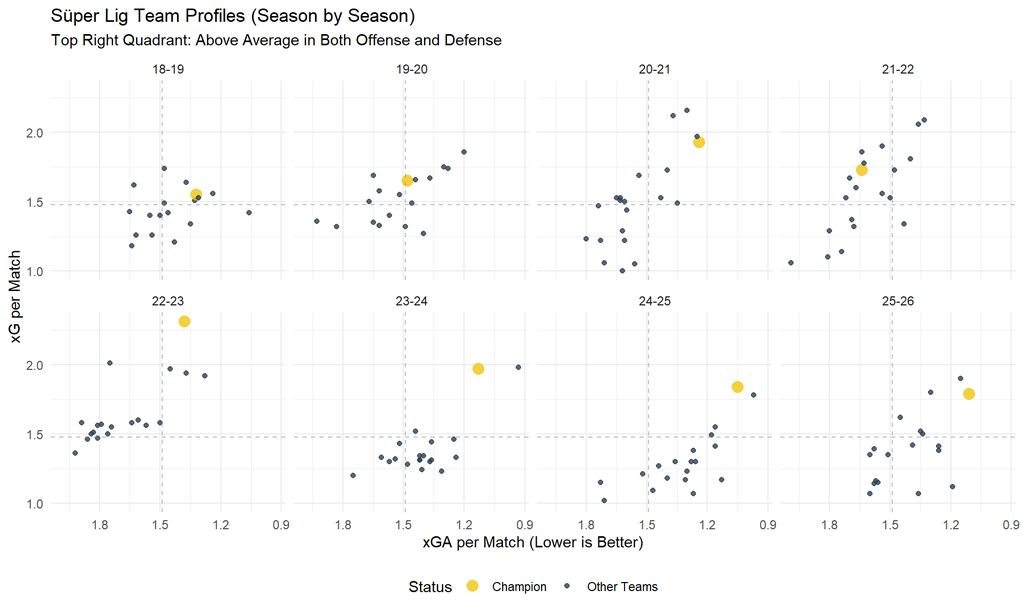

```r
# Quadrant Plot by Season
mean_xg <- mean(analysis_data$xg_for_avg_overall, na.rm = TRUE)
mean_xga <- mean(analysis_data$xg_against_avg_overall, na.rm = TRUE)

ggplot(analysis_data, aes(x = xg_against_avg_overall, y = xg_for_avg_overall)) +
  geom_point(aes(color = is_champion, size = is_champion), alpha = 0.8) +
  geom_hline(yintercept = mean_xg, linetype = "dashed", color = "gray50", alpha = 0.5) +
  geom_vline(xintercept = mean_xga, linetype = "dashed", color = "gray50", alpha = 0.5) +
  scale_color_manual(values = c("Champion" = "#f1c40f", "Other Teams" = "#2c3e50")) +
  scale_size_manual(values = c("Champion" = 3.5, "Other Teams" = 1.5)) +
  scale_x_reverse() +
  facet_wrap(~ Season, ncol = 4) +
  labs(
    title = "Süper Lig Team Profiles (Season by Season)",
    subtitle = "Top Right Quadrant: Above Average in Both Offense and Defense",
    x = "xGA per Match (Lower is Better)",
    y = "xG per Match",
    color = "Status",
    size = "Status"
  ) +
  theme_minimal() +
  theme(legend.position = "bottom")
```

*Analytical Insight:* In the vast majority of seasons, the champion occupies the top-right quadrant. This represents a “systemic dominance.”

### 3.3 The Title Race: When Skill Defies Statistics

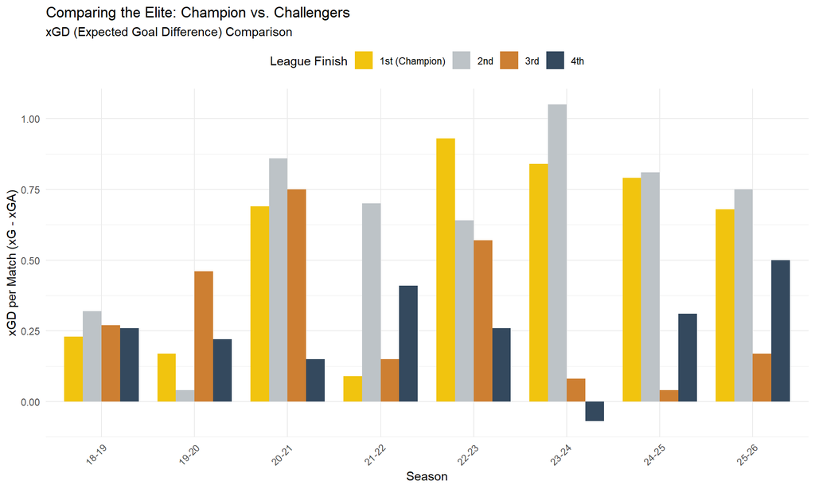

```r
# Top 4 Comparison
top4_data <- analysis_data %>%
  filter(league_position <= 4) %>%
  mutate(Position = case_when(
    league_position == 1 ~ "1st (Champion)",
    league_position == 2 ~ "2nd",
    league_position == 3 ~ "3rd",
    league_position == 4 ~ "4th"
  )) %>%
  mutate(Position = factor(Position, levels = c("1st (Champion)", "2nd", "3rd", "4th")))

ggplot(top4_data, aes(x = Season, y = xGD, fill = Position)) +
  geom_bar(stat = "identity", position = "dodge", width = 0.8) +
  scale_fill_manual(
    values = c(
      "1st (Champion)" = "#f1c40f",
      "2nd" = "#bdc3c7",
      "3rd" = "#cd7f32",
      "4th" = "#34495e"
    )
  ) +
  labs(
    title = "Comparing the Elite: Champion vs. Challengers",
    subtitle = "xGD (Expected Goal Difference) Comparison",
    x = "Season",
    y = "xGD per Match (xG - xGA)",
    fill = "League Finish"
  ) +
  theme_minimal() +
  theme(legend.position = "top", axis.text.x = element_text(angle = 45, hjust = 1))
```

> *Key Takeaway:* “Quality Hands and Quality Feet” matter. Historic goalkeeping performances (elite hands) and ruthless, clinical finishing (elite feet) can occasionally defy mathematical probability.